# RegressionTests

## Regression Tests

This is a document for us to experiment with different regressions.

```r
source("DataCleaner.R")
```

Let’s start with some descriptive statistics to get a feel for our data.

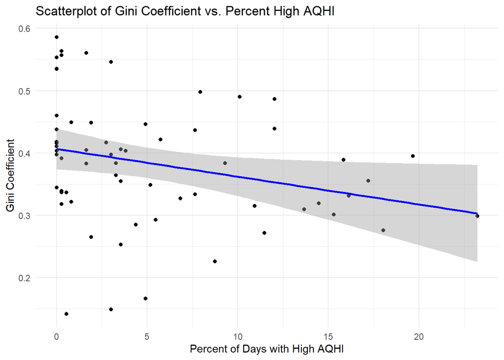

```r
ggplot(d, aes(x = percent_high_AQHI, y = Gini)) + #call ggplot, attach data
  geom_point() + #scatterplot
  labs(
    title = "Scatterplot of Gini Coefficient vs. Percent High AQHI",
    x = "Percent of Days with High AQHI",
    y = "Gini Coefficient" #axis titles
  ) + theme_minimal() + geom_smooth(method = "lm", se = TRUE, color = "blue") #simple regression
```

```r
d |> select(CMAUID, CMANAME, Gini, I0) |> arrange(Gini) |> head(5) |> print()
```

```
# A tibble: 5 × 4
  CMAUID CMANAME                                                 Gini      I0
  <chr>  <chr>                                                  <dbl>   <dbl>
1 934    Squamish                                               0.142 131820.
2 977    Fort St. John                                          0.149 129977.
3 990    Whitehorse                                             0.167 127050.
4 750    Estevan                                                0.226 115560.
5 505    Ottawa - Gatineau (Ontario part / partie de l'Ontario) 0.253 113518.
```

```r
d <- d |> filter(Gini > 0.02)
```

Let’s rerun our scatterplot:

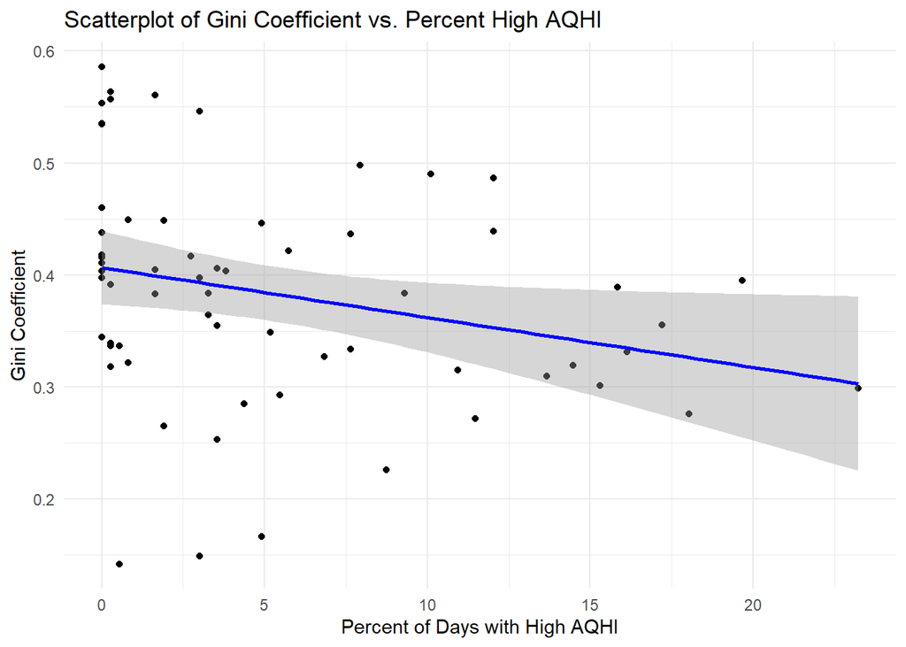

```r
ggplot(d, aes(x = percent_high_AQHI, y = Gini)) + #call ggplot, attach data
  geom_point() + #scatterplot
  labs(
    title = "Scatterplot of Gini Coefficient vs. Percent High AQHI",
    x = "Percent of Days with High AQHI",
    y = "Gini Coefficient" #axis titles
  ) + theme_minimal() + geom_smooth(method = "lm", se = TRUE, color = "blue") #simple regression
```

Let’s try other metrics of AQHI. This could work, but the high number of truncated values seem like a waste of data availability.

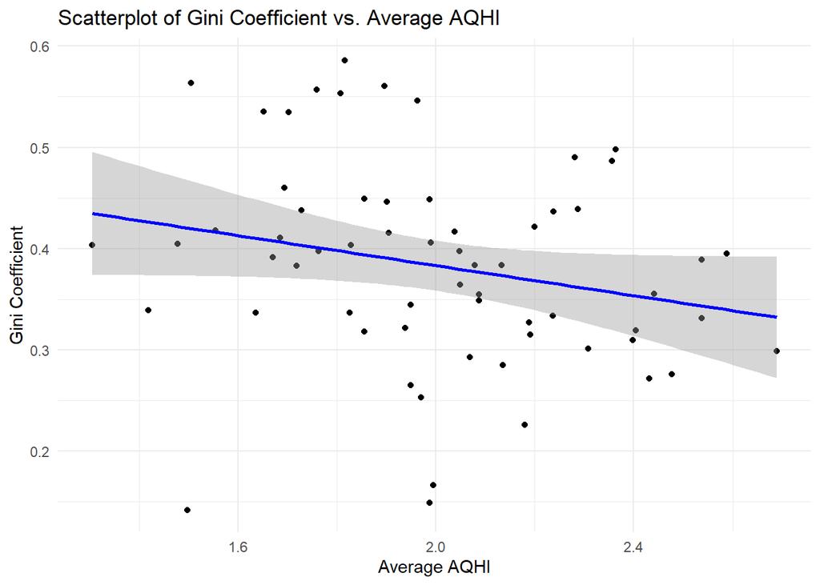

```r
ggplot(d, aes(x = average_AQHI, y = Gini)) + #call ggplot, attach data
  geom_point() + #scatterplot
  labs(
    title = "Scatterplot of Gini Coefficient vs. Average AQHI",
    x = "Average AQHI",
    y = "Gini Coefficient" #axis titles
  ) + theme_minimal() + geom_smooth(method = "lm", se = TRUE, color = "blue") #simple regression
```

```r
d |> select(CMAUID, CMANAME, average_AQHI) |> arrange(average_AQHI) |> head(5) |> print()
```

```
# A tibble: 5 × 3
  CMAUID CMANAME     average_AQHI
  <chr>  <chr>              <dbl>
1 602    Winnipeg            1.31
2 965    Terrace             1.42
3 595    Thunder Bay         1.48
4 934    Squamish            1.50
5 225    Cape Breton         1.51
```

```r
d <- d |> filter(average_AQHI > 1)
```

Trying our scatterplot again:

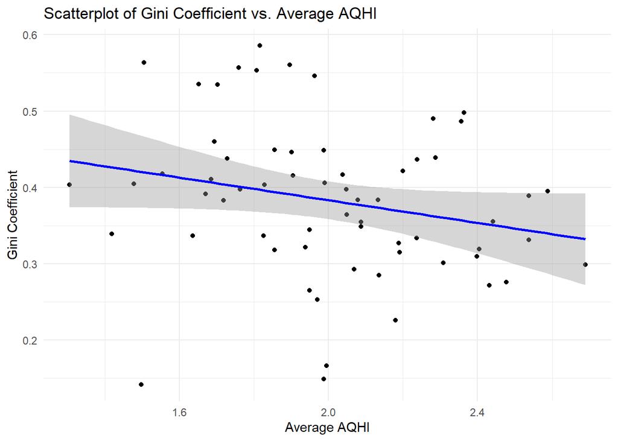

```r
ggplot(d, aes(x = average_AQHI, y = Gini)) + #call ggplot, attach data
  geom_point() + #scatterplot
  labs(
    title = "Scatterplot of Gini Coefficient vs. Average AQHI",
    x = "Average AQHI",
    y = "Gini Coefficient" #axis titles
  ) + theme_minimal() + geom_smooth(method = "lm", se = TRUE, color = "blue") #simple regression
```

I think this is a good choice for our variable. Let’s try a few regressions.

```r
library(car)
library(tidyverse)
library(haven)
library(stargazer)
library(lmtest)
library(sandwich)
```

```r
binreg <- lm(Gini ~ average_AQHI, data = d) #simple regression

summary(binreg) #call
```

```
Call:
lm(formula = Gini ~ average_AQHI, data = d)

Residuals:
      Min        1Q    Median        3Q       Max
-0.278570 -0.056805 -0.003158  0.055224  0.189109

Coefficients:
             Estimate Std. Error t value Pr(>|t|)
(Intercept)   0.53147    0.08069   6.587 1.18e-08 ***
average_AQHI -0.07411    0.03979  -1.863   0.0673 .
---
Signif. codes:  0 '***' 0.001 '**' 0.01 '*' 0.05 '.' 0.1 ' ' 1

Residual standard error: 0.0981 on 61 degrees of freedom
Multiple R-squared:  0.05381,   Adjusted R-squared:  0.0383
F-statistic: 3.469 on 1 and 61 DF,  p-value: 0.06735
```

```r
coeftest(binreg, vcov = vcovHC(binreg, type = "HC1")) #test for heteroskedasticity
```

```
t test of coefficients:

              Estimate Std. Error t value Pr(>|t|)
(Intercept)   0.531470   0.080260  6.6219 1.03e-08 ***
average_AQHI -0.074106   0.037570 -1.9725  0.05309 .
---
Signif. codes:  0 '***' 0.001 '**' 0.01 '*' 0.05 '.' 0.1 ' ' 1
```

Let’s add in our control variables. We want to have an interaction variable between average_AQHI and aggregate income: we can expect air quality to effect income inequality differently in places with higher or lower incomes. We will use average (mean) income as a proxy for aggregate income; adding in this interaction will not introduce endogeneity, as mean income was not used in our calculation of the Gini coefficient.

```r
fullreg <- lm(Gini ~ average_AQHI + male + vismin + immigrant + married + not_eng_fr + employed + university + average_AQHI:avg_income, data = d)

summary(fullreg)
```

```
Call:
lm(formula = Gini ~ average_AQHI + male + vismin + immigrant +
    married + not_eng_fr + employed + university + average_AQHI:avg_income,
    data = d)

Residuals:
      Min        1Q    Median        3Q       Max
-0.135772 -0.025392  0.003538  0.025854  0.086905

Coefficients:
                          Estimate Std. Error t value Pr(>|t|)
(Intercept)              2.042e+00  4.669e-01   4.373 5.76e-05 ***
average_AQHI             2.947e-01  4.026e-02   7.321 1.38e-09 ***
male                    -3.220e-02  8.070e-03  -3.990 0.000204 ***
vismin                   5.009e-03  2.498e-03   2.005 0.050055 .
immigrant               -5.949e-03  2.809e-03  -2.118 0.038886 *
married                  2.018e-03  2.505e-03   0.806 0.424101
not_eng_fr              -1.833e-02  1.295e-02  -1.416 0.162667
employed                -1.871e-03  2.994e-03  -0.625 0.534684
university              -1.876e-03  1.251e-03  -1.500 0.139548
average_AQHI:avg_income -4.503e-06  5.363e-07  -8.395 2.63e-11 ***
---
Signif. codes:  0 '***' 0.001 '**' 0.01 '*' 0.05 '.' 0.1 ' ' 1

Residual standard error: 0.04305 on 53 degrees of freedom
Multiple R-squared:  0.8417,    Adjusted R-squared:  0.8148
F-statistic: 31.31 on 9 and 53 DF,  p-value: < 2.2e-16
```

This looks a lot better, but we should center and categorize our `avg_income` to make the model more clear to interpret and avoid problems of non-linearity in their interaction.

```r
mean_income <- mean(d$avg_income)
d <- d |> mutate(centered_avg_income = avg_income - mean_income)
```

We need to fix a grouping in our data.

```r
d <- d |> ungroup()
```

```r
d <- d |>
  mutate(income_cat = factor(ntile(avg_income, 3), labels = c("Low", "Mid", "High")))
```

Now let’s try the new regression.

```r
regression7 <- lm(Gini ~ average_AQHI + male + vismin + immigrant + married + not_eng_fr + employed + university + average_AQHI:income_cat, data = d)

summary(regression7)
```

```
Call:
lm(formula = Gini ~ average_AQHI + male + vismin + immigrant +
    married + not_eng_fr + employed + university + average_AQHI:income_cat,
    data = d)

Residuals:
      Min        1Q    Median        3Q       Max
-0.123937 -0.026204 -0.003519  0.040325  0.096523

Coefficients:
                             Estimate Std. Error t value Pr(>|t|)
(Intercept)                  3.411065   0.477130   7.149 2.86e-09 ***
average_AQHI                 0.059105   0.026396   2.239 0.029448 *
male                        -0.054360   0.008681  -6.262 7.41e-08 ***
vismin                       0.001903   0.002887   0.659 0.512685
immigrant                   -0.003691   0.003324  -1.111 0.271884
married                      0.000917   0.002965   0.309 0.758322
not_eng_fr                  -0.000768   0.014601  -0.053 0.958252
employed                    -0.003765   0.003524  -1.068 0.290391
university                  -0.002475   0.001487  -1.665 0.101991
average_AQHI:income_catMid  -0.033577   0.008571  -3.918 0.000262 ***
average_AQHI:income_catHigh -0.059229   0.009874  -5.998 1.94e-07 ***
---
Signif. codes:  0 '***' 0.001 '**' 0.01 '*' 0.05 '.' 0.1 ' ' 1

Residual standard error: 0.05074 on 52 degrees of freedom
Multiple R-squared:  0.7842,    Adjusted R-squared:  0.7427
F-statistic:  18.9 on 10 and 52 DF,  p-value: 5.218e-14
```

Great! This interaction variable was definitely relevant. Thank you Prerna for the recommendation!

I am updating DataCleaner.R with our relevant code.